# Interactive Plots

Tyler Hill

3/10/2021

```r
# Load libraries
library(tidyverse)
library(leaflet)
library(sf)
library(htmltools)
library(tigris)
library(highcharter)

# Load in the data
data_f <- file.path(".", "data.RData")
load(data_f)
```

# Terry Stop Map

I will work with data only from 2018 just to get the map working. I will filter the df in the subsequent shiny app with a slider so the user can select the year they want to see data for.

```r
# Subset the data for 2018
terry_2018 <- terry_df %>%
  filter(Year == 2018)

# Number of Terry Stops
nrow(terry_2018)
```

```
## [1] 6875
```

```r
# Df of total terry stops that year per beat
beat_stops <- terry_2018 %>%
  group_by(Beat) %>%
  summarise(total_stops = n())

# Add missing beats data to beat_stops
dif_beats <- setdiff(beats$beat, beat_stops$Beat)
for (b in dif_beats) {
  beat_stops <- beat_stops %>%
    add_row(Beat = b, total_stops = 0)
}

# Combine terry stop data into the shapefile
beats <- geo_join(beats, beat_stops, "beat", "Beat")
# Set chloropleth color palette
bins <- c(0, 20, 50, 90, 140, 200, 270, Inf)
pal <- colorBin("YlGnBu", domain = beats$total_stops, bins = bins)

beat_info <- paste(
    "Beat: ", beats$beat,"<br/>",
    "Terry Stops: ", beats$total_stops, "<br/>",
    sep="") %>%
  lapply(htmltools::HTML)

terry_map <- leaflet(options = leafletOptions(minZoom = 10)) %>%
  addTiles() %>%
  addPolygons(data = beats,
              stroke = 1,
              weight = 1,
              color = "grey",
              fillColor = ~pal(total_stops),
              fillOpacity = 0.5,
              label = beat_info,
              highlight = highlightOptions(
                weight = 3,
                color = "#666",
                fillOpacity = 0.7,
                bringToFront = TRUE)) %>%
  addLegend(pal = pal,
            values = beats$total_stops,
            opacity = 0.6,
            title = NULL,
            position = "bottomright") %>%
  setView((-122.4597 + -122.2244)/2, (47.48173+47.74913)/2, 10) %>%
  setMaxBounds(-122.4597, 47.74913,  -122.2244, 47.48173)

terry_map
```

[interactive chart not shown]

The above chloropleth shows the total number of Terry stops in each beat for the year of 2018 by hovering over the beat in question. It also quickly shows relative frequency between the beats visually as per the legend.

Next I will make summarizing visualizations to display next to the map. These will summarize the data for all the beats combined. Hopefully, I will be able to subset the data per beat in the shiny app when the user clicks on a beat in the map above.

```r
# Age of subject
sub_age_chart <- terry_2018 %>%
  group_by(Subject.Age.Group, Subject.Perceived.Gender) %>%
  summarise(age_count = n()) %>%
  hchart(
    "column", hcaes(
      x = Subject.Age.Group,
      y = age_count,
      group = Subject.Perceived.Gender),
    stacking = "normal"
  ) %>%
  hc_xAxis(title = list(text = "Subject Age")) %>%
  hc_yAxis(title = list(text = "Frequency")) %>%
  hc_title(text = "Subject Age Distribution")
sub_age_chart
```

[interactive chart not shown]

It looks like the 26 to 35 age group is by far targeted most often for Terry Stops.

Next I will look at a pie chart of subject race.

```r
sub_race_pie <- terry_2018 %>%
  group_by(Subject.Perceived.Race) %>%
  summarise(count = n()) %>%
  hchart(
    "pie", hcaes(x = Subject.Perceived.Race, y = count),
    name = "Frequency"
  ) %>%
  hc_title(text = "Subject Race")
sub_race_pie
```

[interactive chart not shown]

It looks like about half of Terry Stops in Seattle are conducted on white people, with the next highest group being black or African American people with just over a quarter of total stops.

Let’s look at some summarizing statistics for the police next.

```r
pol_age_chart <- terry_2018 %>%
  group_by(Officer.Age, Officer.Gender) %>%
  mutate(Officer.Age = cut(Officer.Age, breaks = c(18, 25, 35, 45, 55, 100))) %>%
  summarise(age_count = n()) %>%
  hchart(
    "column", hcaes(
      x = Officer.Age,
      y = age_count,
      group = Officer.Gender),
    stacking = "normal"
  ) %>%
  hc_xAxis(title = list(text = "Officer Age"),
           categories = as.list(c("18 - 25", "26 - 35", "36 - 45", "46 - 55", "56 +"))) %>%
  hc_yAxis(title = list(text = "Frequency")) %>%
  hc_title(text = "Officer Age Distribution")
pol_age_chart
```

[interactive chart not shown]

```r
pol_race_pie <- terry_2018 %>%
  group_by(Officer.Race) %>%
  summarise(count = n()) %>%
  hchart(
    "pie", hcaes(x = Officer.Race, y = count),
    name = "Frequency"
  ) %>%
  hc_title(text = "Officer Race")
pol_race_pie
```

[interactive chart not shown]

White officers by far comprise the majority of officers conducting Terry Stops, with about three quarters of all stops in 2018.

Next I will see the proportion of how Terry Stops resolved

```r
arrest_pie <- terry_2018 %>%
  group_by(Stop.Resolution) %>%
  summarise(count = n()) %>%
  hchart(
    "pie", hcaes(x = Stop.Resolution, y = count),
    name = "Frequency"
  ) %>%
  hc_title(text = "Terry Stop Resolution")
arrest_pie
```

[interactive chart not shown]

It looks like most Terry Stops result in an Offense Reported or an Arrest.

Next I will look at what time of day do most Terry Stops occur.

```r
time_of_day <- terry_2018 %>%
  group_by(Time) %>%
  summarise(count = n()) %>%
  hchart(
    "column", hcaes(
      x = Time,
      y = count
      ),
    name = "Frequency"
    ) %>%
  hc_chart(polar = TRUE) %>%
  hc_title(text = "Terry Stop Time of Day (24 hr)") %>%
  hc_xAxis(
    categories = as.list(paste(0:23, ":00", sep = ""))
    )
time_of_day
```

[interactive chart not shown]

From the above chart we can see that most stops happen in the evening and the least in the morning.

## In Summary

Below we can see the layout I came up with in my concept sketches. This shows how the above figures will ultimately be arranged in the shiny app. Not all the same information is available for each Category but I will keep what summary visualizations I can. Also, only long/lat is available for the shootings data so I will just show their exacts locations on the map.

NOTE: I am only using data for the years 2018 through 2020 now.

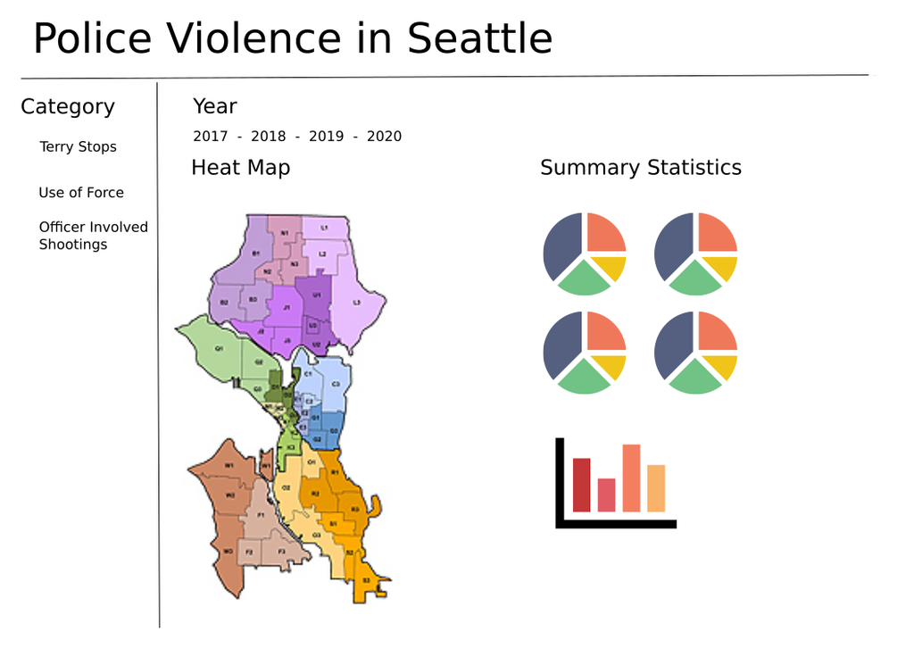

Concept Sketch of Shiny App